# R Markdown - HW2

曾意儒 Yi-Ju Tseng  
2017/03/06

### R Markdown

[figure not shown]

投影片和書都是以R Markdown為基礎編寫而成

### R Markdown

- 用來"溝通"：資料分析的最後一步
- 包含**程式碼**與**分析結果**，可與其他資料科學家分享
- 可重現分析結果的文件 （分析/實驗再現性高）
- 支援各種輸出格式：Slides, PDF, HTML. Word,…

### R Markdown

- http://rmarkdown.rstudio.com/
- R + Markdown (基於Markdown文件)
- 所有寫在**R Code Chunks**的R程式碼都會執行，並將結果輸出
- 輸出選擇：
  - 文件：HTML, PDF, Word
  - 投影片：HTML, PDF
  - Shiny
  - 模板：放上GitHub使用的.md檔

### R Markdown - New File

[figure not shown]

### R Markdown - 輸出文件

[figure not shown]

### R Markdown - 輸出投影片

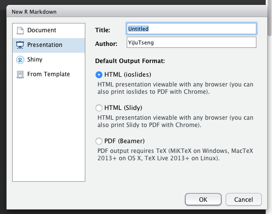

### R Markdown - 輸出模板（GitHub）

[figure not shown]

### R Markdown & Markdown

**R Markdown** (.Rmd) —knitr—> **Markdown** (.md)

**Markdown** (.md) —markdown—> **HTML**

邊寫完.Rmd檔後，按下**knit**按鈕，輸出PDF/HTML/Markdown

### Markdown 基本語言

Heading

- `#`
- `##`
- `###`

List

- `-`
  - `(tab)-`

### Markdown 基本語言

圖

- `![alt text](http://example.com/logo.png)`

連結

- `[website name](url)`

### R Markdown @RStudio

Step 1 開啟新的R Markdown 檔案

[figure not shown]

### R Markdown @RStudio

Step 2 設定輸出格式

最後要放上GitHub，所以選From Template裡的GitHub Document

[figure not shown]

### R Markdown @RStudio

Step 3 設定文件基本資訊

title: “Untitled”

output: github_document

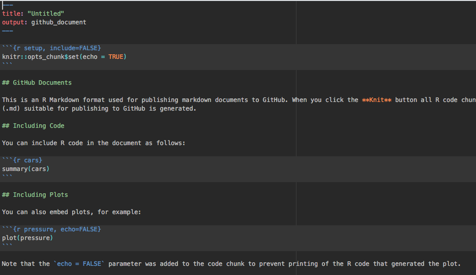

### R Code Chunk的參數

- eval：要不要**執行並顯示**在輸出的Markdown檔案內
- echo：要不要一起**顯示程式碼**(不顯示程式碼仍會執行，但只顯示執行結果)
- warning, error, message：要不要顯示錯誤訊息
- cache：是否要暫存結果

### Table

若需要輸出表格，預設的輸出方式如下：

```r
mtcars[1:5, 1:5]
```

```
                   mpg cyl disp  hp drat
Mazda RX4         21.0   6  160 110 3.90
Mazda RX4 Wag     21.0   6  160 110 3.90
Datsun 710        22.8   4  108  93 3.85
Hornet 4 Drive    21.4   6  258 110 3.08
Hornet Sportabout 18.7   8  360 175 3.15
```

### Table (knitr::kable)

如果想要呈現的更清楚，建議使用**knitr::kable**

```r
knitr::kable(
  mtcars[1:5, 1:5], caption = "A knitr kable."
)
```

|  | mpg | cyl | disp | hp | drat |
| --- | --- | --- | --- | --- | --- |
| Mazda RX4 | 21.0 | 6 | 160 | 110 | 3.90 |
| Mazda RX4 Wag | 21.0 | 6 | 160 | 110 | 3.90 |
| Datsun 710 | 22.8 | 4 | 108 | 93 | 3.85 |
| Hornet 4 Drive | 21.4 | 6 | 258 | 110 | 3.08 |
| Hornet Sportabout | 18.7 | 8 | 360 | 175 | 3.15 |

### HW2

作業目的：練習撰寫R Markdown文件、熟悉GitHub操作方式、練習基礎的R程式碼

- 點開GitHub作業邀請連結
- GitHub自動將作業模板新增至你的個人帳號
- 將作業Repo clone至本機端
- 按照作業模板指示完成第一份R的分析（？）報告！
- Commit & Sync
- 將Repo網址與SHA號碼繳交至eLearning系統
- 3/20 (一) 11:59pm繳交